# Project 3: College-level Analysis

Madison Corinha

May 10, 2020

MATH 228: Introduction to Data Science is a college course, and the work for this course (at the very least) must match the quality of work generally expected from an undergraduate-level student. For this project, you could say that a “college-level analysis” is required. What better data is there to perform a *“college-level analysis”* with than data *actually about colleges*!

The four datasets I will be using from this TidyTuesday page are named as follows: `tuition_cost`, `tuition_income`, `salary_potential` and `diversity_school`.

You can find the TidyTuesday page for these data [here](https://github.com/rfordatascience/tidytuesday/blob/master/data/2020/2020-03-10/readme.md).

## Research questions:

- Does one state have a higher avaerage tuition than any other states?
- Is there an association between percent of students enrolled that are women and tuition?
- Are there any trends in the difference between total cost for tuition and net cost for tuition (average actually paid after scholarships/awards)?
- Can we predict the percent of alumni that think they are making the world a better place using factors about the school they graduated from such as tuition price, type of school, year degree, state, etc.?

Let’s start with this question:

> Does one state have a higher in-state tuition than any other states?

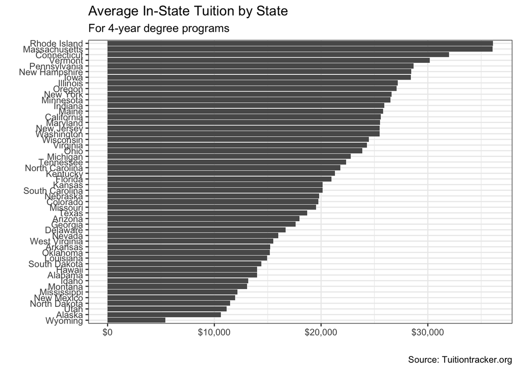

```r
tuition_cost %>%
  filter(degree_length == "4 Year") %>% # only looking at 4 year colleges
  group_by(state) %>%
  summarise(av_in_state_tu = mean(in_state_tuition)) %>% # creating variable for average in-state tuition for whole state
  na.omit() %>% # get rid of empty/NA state values
  ggplot(aes(x = fct_reorder(state, av_in_state_tu), y = av_in_state_tu)) + # fct_reorder() organizes bars in descending order (it looks WAY better!)
  geom_col() +
  theme_bw() + # my favorite theme right after theme_void()
  coord_flip() +
  labs(x = "", y = "", # x and y axis labels are redundant here
       title = "Average In-State Tuition by State",
       subtitle = "For 4-year degree programs",
       caption = "Source: Tuitiontracker.org") +
  scale_y_continuous(labels = scales::dollar_format()) # makes y axis labels into $ with commas
```

New England states are dominating the top spots for average in-state tuition. Rhode island has the most expensive average in-state tuition at $36,114.90, and Massachusetts is a very close second at $36,081.24 . Wyoming has a surprisingly low average in-state tuition at an even $5,400.

If this were a race, Rhode Island and Massachusetts would have a solid lead over the other 48 states - but this isn’t a race, and I don’t think anyone would actually want their state to win.

Moving away from state data…

This might be a long shot, but all is fair in Data Exploration!

> Is there an association between percent of students enrolled that are women and tuition? Do women tend to go to pricey schools?

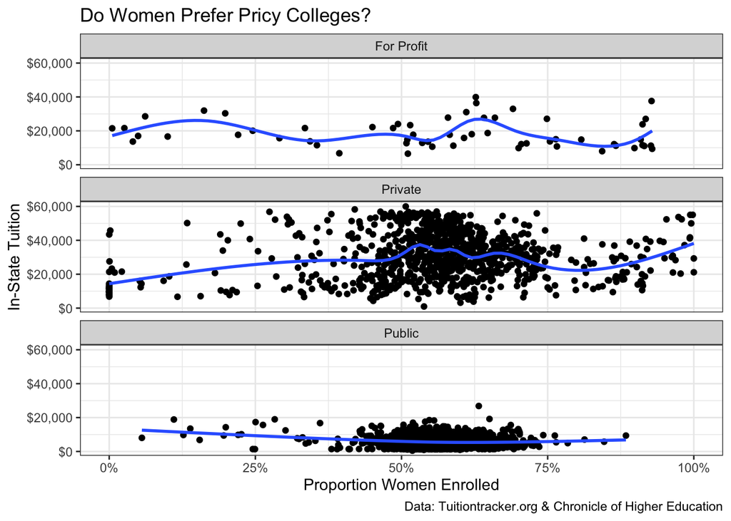

```r
tuition_cost %>%
  left_join(diversity_school, by = c("name", "state")) %>% # join together tuition_income and diversity_school data
  filter(category == "Women") %>%
  mutate(per_women = enrollment / total_enrollment) %>% # create a variable for percent of women enrolled
  ggplot(aes(x = per_women, y = in_state_tuition)) +
  geom_point() +
  geom_smooth(se = F) +
  facet_wrap(~ type, nrow = 3) +
  theme_bw() +
  labs(x = "Proportion Women Enrolled", y = "In-State Tuition",
       caption = "Data: Tuitiontracker.org & Chronicle of Higher Education", # tuition_cost from Tuitiontracker.org; diversity_school from Chron. Higher Ed
       title = "Do Women Prefer Pricy Colleges?") +
  scale_y_continuous(labels = scales::dollar_format()) + # make Y axis labels $
  scale_x_continuous(labels = scales::percent_format()) # make X axis labels %
```

There doesn’t seem to be any clear association between percentage of women enrolled and tuition price, so I will not go any futher into this question. I did remember an interesting tid-bit while looking at this data visualization: “All boys” or “All women” schools are usually private schools, because single-sex public schools won’t get financial aid from the government!

Specific information about the laws regarding this can be can be found [on the wikipedia page for single-sex education](https://en.wikipedia.org/wiki/Single-sex_education#United_States).

After the last research question didn’t give us any particularly interesting trends, I have high hopes for this next question!

The `tuition_income` dataset includes a variable called `net_cost` that represents the “average amount actually paid after scholarship/award” for each of 5 levels of `income_bracket` for each school across several years.

> Are there any trends in the difference between total cost for tuition and net cost for tuition (average actually paid after scholarships/awards)?

In order to do this, I first filtered the data so we were only looking at data from 2018 for each school. I didn’t need to keep net cost separated by income level, so I made an aggregate summary statistic for average net cost across all income levels (`av_net`) using `summarize()`. Since I can’t use `mutate()` to create a new variable from an aggregate summary stat and a single data point, I made a second aggregate summary statistic for the average total price of tuition called `av_total` in the `summarize()` function (the values for `total_price` that I’m aggregating here should all be the same exact number so taking `mean(total_price)` shouldn’t change anything). Now that they are both aggregate summary stats grouped by college name, I can use them both in a `mutate()` to create a variable representing the **average** percent of tuition actually paid. From there, I created a histogram to provide a visualization of the distribution of the average percent of tuition that is actually paid for each school.

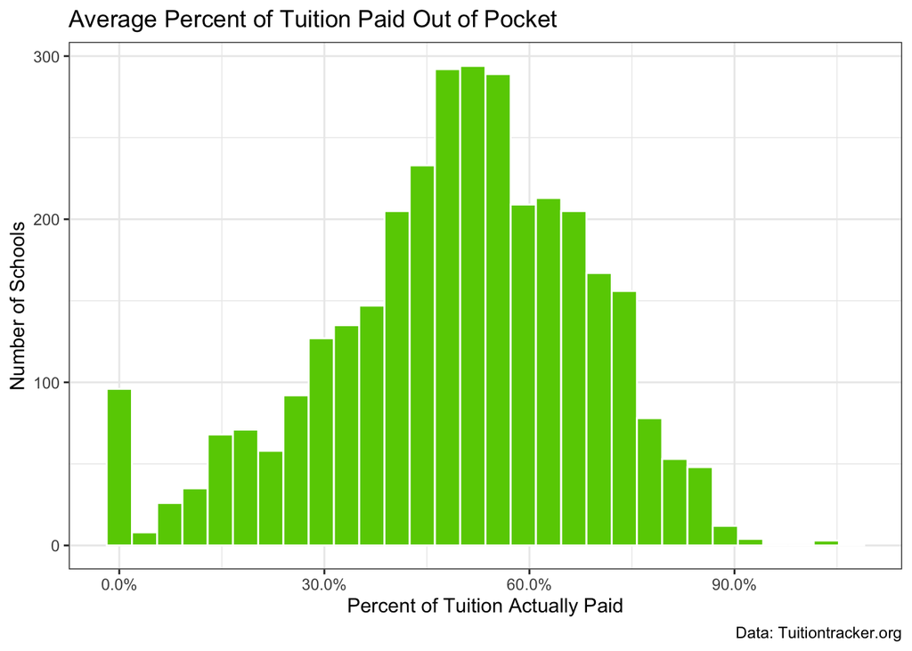

```r
tuition_income %>%
  filter(year == "2018") %>% #only looking at 2018 data to make this a little less complicated
  group_by(name) %>%
  summarize(av_net = mean(net_cost), # create a variable for average net cost (for all income levels)
            av_total = mean(total_price)) %>% # need to do this to get aggregate summary stat of total cost
  mutate(per_paid = av_net / av_total) %>%
  ggplot(aes(x = per_paid)) +
  geom_histogram(color = "white", fill = "chartreuse3") + # I had to put this color in somewhere :)
  theme_bw() +
  labs(x = "Percent of Tuition Actually Paid", y = "Number of Schools",
       caption = "Data: Tuitiontracker.org",
       title = "Average Percent of Tuition Paid Out of Pocket") +
  scale_x_continuous(labels = scales::percent_format()) # make X axis labels %
```

According to this histogram, the most common percentages of tuition actually paid is centered around 50%. The mean percent of tuition actually paid is 49.04%, with a standard deviation of 19.23%. The median percent of tuition actually paid is 50.71%. The number of schools with an average of 0% tuition actually paid is very surprising, and is probably due to missing values or data entry errors, as it does not make sense. This is troubling to see, as it raises questions about the validity of the data.

> The above data visualization uses the *average* net cost *for all income levels*. What if we keep the data separated by income level?

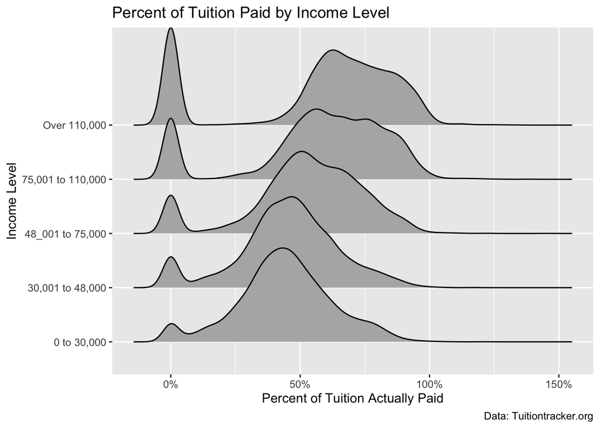

```r
tuition_income %>%
  filter(year == "2018") %>% # still just focusing on 2018 data
  mutate(per_paid = net_cost / total_price) %>%
  ggplot(aes(x = per_paid, y = income_lvl)) +
  geom_density_ridges() +
  labs(x = "Percent of Tuition Actually Paid", y = "Income Level",
       caption = "Data: Tuitiontracker.org",
       title = "Percent of Tuition Paid by Income Level") +
  scale_x_continuous(labels = scales::percent_format())
```

Percent of tuition actually paid seems to increase as income level increases, suggesting that financial aid is possibly given based on need.

> What if we also separated this based on school type (Public, Private, For-Profit)?

In order to do this, we have to join together the `tuition_income` data with the `tuition_cost` data:

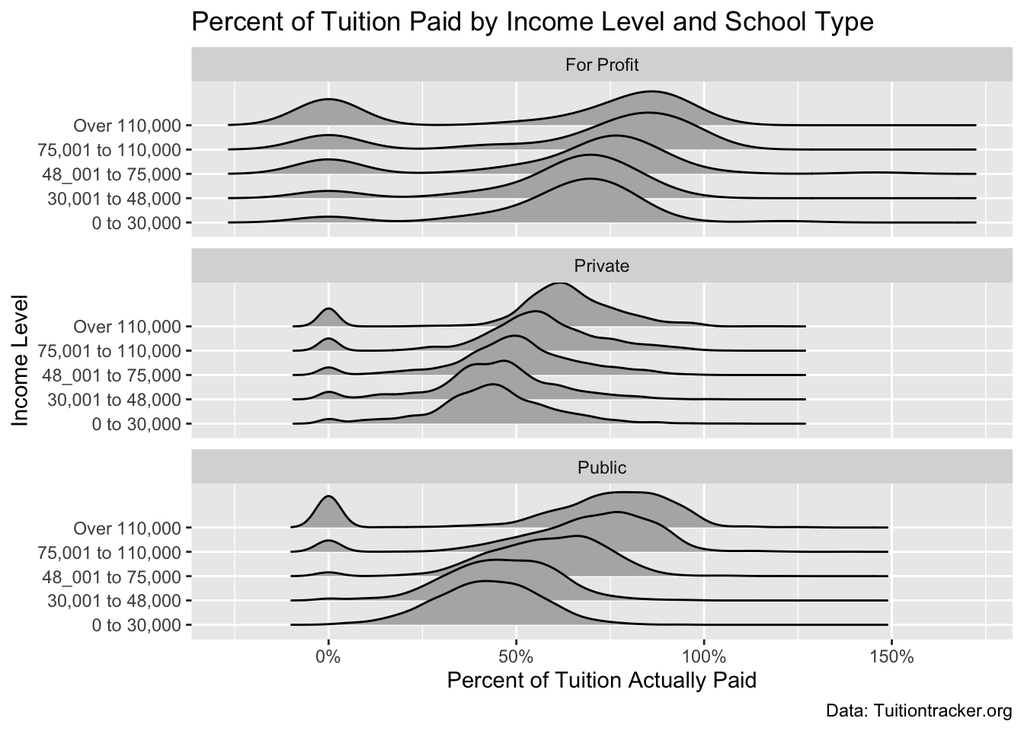

```r
tuition_cost_short = tuition_cost %>%
  select(name, state, state_code, type)

tuition_new = tuition_income %>%
  rename(state_code = state) %>%
  filter(year == "2018") %>%
  inner_join(tuition_cost_short, by = c("name", "state_code")) %>%
  mutate(per_paid = net_cost / total_price)

ggplot(tuition_new, aes(x = per_paid, y = income_lvl)) +
  geom_density_ridges() +
  facet_wrap(~ type, nrow = 3) +
  labs(x = "Percent of Tuition Actually Paid", y = "Income Level",
       caption = "Data: Tuitiontracker.org",
       title = "Percent of Tuition Paid by Income Level and School Type") +
  scale_x_continuous(labels = scales::percent_format())
```

All three school types (For-Profit, Public, & Private) show an increase in average percent of tuition actually paid as income level increases. Density plots for For-Profit schools were all centered around 73%-85% of tuition actually paid. Density plots for Private colleges seemed to be centered around 45%-60% of tuition actually paid, and density plots for Public colleges seemed to be centered from 45%-75% of tuition actually paid. For-Profit schools seem to have much higher percentages paid for all income levels than both Public and Private schools do.

One of the parts of the data that we havent talked about yet is a dataset called `salary_potential`. In that dataset, there is a really cool variable called `make_world_better_percent` that represents “the percent of alumni who think they are making the world a better place”.

> Can we predict the percent of alumni that think they are making the world a better place using factors about the school they graduated from such as tuition price, type of school, year degree, state, etc.?

I’m going to try this with both a linear model and a decision tree, then compare model performance by looking at the RMSE.

```r
# First we have to clean the data and join salary_potential + tuition_cost to make a new dataset
tuition_potential = salary_potential %>%
  mutate(state_name = str_replace(state_name, pattern = "New-Jersey", replacement = "New Jersey")) %>%
  mutate(state_name = str_replace(state_name, pattern = "New-York", replacement = "New York")) %>%
  mutate(state_name = str_replace(state_name, pattern = "New-Hampshire", replacement = "New Hampshire")) %>%
  mutate(state_name = str_replace(state_name, pattern = "New-Mexico", replacement = "New Mexico")) %>%
  mutate(state_name = str_replace(state_name, pattern = "North-Carolina", replacement = "North Carolina")) %>%
  mutate(state_name = str_replace(state_name, pattern = "North-Dakota", replacement = "North Dakota")) %>%
  mutate(state_name = str_replace(state_name, pattern = "Rhode-Island", replacement = "Rhode Island")) %>%
  mutate(state_name = str_replace(state_name, pattern = "South-Carolina", replacement = "South Carolina")) %>%
  mutate(state_name = str_replace(state_name, pattern = "South-Dakota", replacement = "South Dakota")) %>%
  mutate(state_name = str_replace(state_name, pattern = "West-Virginia", replacement = "West Virginia")) %>%
  rename(state = state_name) %>%
  inner_join(tuition_cost, by = c("name", "state"))

# Data splitting!

set.seed(1209)
tuit_split = initial_split(tuition_potential, prop = 0.7)

tuit_train = training(tuit_split)
tuit_test = testing(tuit_split)

# Linear Regression Model

lm_fit = linear_reg() %>%
  set_engine(engine = "lm") %>%
  fit(make_world_better_percent ~ in_state_total + state + type + stem_percent, data = tuit_train)

lm_pred = lm_fit %>%
  predict(new_data = tuit_test)

tuit_test %>%
  mutate(worldbetter_pred = lm_pred$.pred) %>%
  rmse(truth = make_world_better_percent, estimate = worldbetter_pred)
```

```
## # A tibble: 1 x 3
##   .metric .estimator .estimate
##   <chr>   <chr>          <dbl>
## 1 rmse    standard        7.57
```

```r
# Decision Tree Model

fit_tree = decision_tree() %>%
  set_engine(engine = "rpart") %>%
  set_mode(mode = "regression") %>%
  fit(make_world_better_percent ~ in_state_total + state + type + stem_percent, data = tuit_train)

pred_tree = fit_tree %>%
  predict(new_data = tuit_test)

tuit_test %>%
  mutate(worldbetter_pred = pred_tree$.pred) %>%
  rmse(truth = make_world_better_percent, estimate = worldbetter_pred)
```

```
## # A tibble: 1 x 3
##   .metric .estimator .estimate
##   <chr>   <chr>          <dbl>
## 1 rmse    standard        8.77
```

The root mean squared error (RMSE) is lower for the linear regression model (7.57) than it is for the decision tree model (8.77), suggesting that the linear regression model is the “better” fit model.

If you have stuck with this so far, I hope you learned something interesting about college tuition data! I had fun exploring some intereting research questions for this project, and I hope it is fun for anyone who reads this too.